# Dynamena pumila project

Kupaeva DM

15 12 2020

# Reference assembly

In this step we used next libraries: * pre-prepared data from different stages of development *Dynamena pumila* colony, NGS paired reads, 150 nt long; * 3 library with sequences from growing tip, 100 nt, single end; * 3 library with sequences from hydrant, 100 nt, single end; * 3 library with sequences from growing tip, 100 nt, single end, alternative way of dna extraction.

## Data preparing:

Trimming adapters and bad-quality bases:

```
/home/kremnyov-lab/Загрузки/fastp -i /media/kremnyov-lab/data2/20080351/fastq/3_ACTTGAAT_L001_R1_001.fastq --out1 /media/kremnyov-lab/data2/20080351/fastq/3_fastp.fastq -l 36 -f 12 --adapter_sequence ACTTGAAT -h 3_fastp
```

Kraken databases preparing:

```
/media/kremnyov-lab/data2/kracken_db/kraken2-master/scripts/kraken2-build --download-taxonomy --db /media/kremnyov-lab/data2/kracken_db/kracken_custom

/media/kremnyov-lab/data2/kracken_db/kraken2-master/scripts/kraken2-build --download-library plant --db /media/kremnyov-lab/data2/kracken_db/kracken_custom

/media/kremnyov-lab/data2/kracken_db/kraken2-master/scripts/kraken2-build --build --db /media/kremnyov-lab/data2/kracken_db/kracken_custom
```

Filtering contamination:

```
/media/kremnyov-lab/data2/kracken_db/kraken2-master/scripts/kraken2 --db /media/kremnyov-lab/data2/kracken_db/kracken_custom --fastq-input 1_fastp.fastq --threads 15 --classified-out 1_contaminat.fastq --unclassified-out 1_dif_kraken.fastq
```

By the reason of limited computing resources, before assembly we prepare digital normalization of our data:

```
/media/kremnyov-lab/data2/bbmap/bbnorm.sh in=/media/kremnyov-lab/data2/20080351/fastq/1_dif_kraken.fastq  out=/media/kremnyov-lab/data2/20080351/fastq/*_dif_norm.fastq
```

## Transcroptome assembly and check quality of data:

[output not shown]

For estimate basic statistics of assembly we used app from Trinity assembler:

```
/home/kremnyov-lab/Загрузки/trinityrnaseq-v2.8.6/util/TrinityStats.pl /media/kremnyov-lab/data2/20080351/fastq/dt_spades/hard_filtered_transcripts.fasta
```

```
################################
Counts of transcripts, etc.
################################
Total trinity 'genes':  98592
Total trinity transcripts:  98592
Percent GC: 38.16

########################################
Stats based on ALL transcript contigs:
########################################

Contig N10: 7777
Contig N20: 5615
Contig N30: 4443
Contig N40: 3659
Contig N50: 3041

Median contig length: 1278
Average contig: 1877.16
Total assembled bases: 185073139
```

For estimate transcriptome completeness we used BUSCO with metazoa genes databases:

```
python3 /media/kremnyov-lab/DATA/19062651/busco-master/scripts/run_BUSCO.py -i /media/kremnyov-lab/data2/20080351/fastq/dt_spades/hard_filtred_transcripts.fasta -o BUSCO_hard_spades -l /media/kremnyov-lab/DATA/19062651/busco-master/metazoa_odb9 -m tran -c 5
```

```
C:95.9%[S:43.9%,D:52.0%],F:1.0%,M:3.1%,n:978

938 Complete BUSCOs (C)
429 Complete and single-copy BUSCOs (S)
509 Complete and duplicated BUSCOs (D)
10  Fragmented BUSCOs (F)
30  Missing BUSCOs (M)
978 Total BUSCO groups searched
```

## Transcriptome filtering

For filtering reference transcriptome we used CD-HIT-EST, which cluster sequences and filtered sequences which are similar than 0.9.

```
./cd-hit-est -i /media/kremnyov-lab/data2/20080351/fastq/hf_transcripts.fasta -o /media/kremnyov-lab/data2/20080351/fastq/hhf_transcripts.fasta -T 15
```

And we translated transcriptome:

```
/home/kremnyov-lab/miniconda3/bin/TransDecoder.LongOrfs -t./hhf_transcripts.fasta -m 100 --output_dir ./orfs

/home/kremnyov-lab/miniconda3/bin/TransDecoder.Predict -t /media/kremnyov-lab/DATA/19062651/fastq/dynamena_transcriptome/transcripts_1306.fasta --output_dir /media/kremnyov-lab/DATA/19062651/fastq/dynamena_transcriptome/transdecoder
```

# Annotation of reference transcrioptome

For annotation we used: * EggNog web-serwer * Trinotate pipeline

```
/home/kupaeva/miniconda3/bin/Build_Trinotate_Boilerplate_SQLite_db.pl Trinotate

makeblastdb -in uniprot_sprot.pep -dbtype prot

gunzip Pfam-A.hmm.gz

hmmpress Pfam-A.hmm

blastx -query hhf_transcripts.fasta -db uniprot_sprot.pep -num_threads 8 -max_target_seqs 1 -outfmt 6 -evalue 1e-3 > blastx.outfmt6

blastp -query longest_orfs.fasta -db uniprot_sprot.pep -num_threads 8 -max_target_seqs 1 -outfmt 6 -evalue 1e-3 > blastp.outfmt6

hmmscan --cpu 5 --domtblout TrinotatePFAM.out Pfam-A.hmm longest_orfs.fasta > pfam.log
```

- blastp annotation with using SwissProt data

```
/home/kremnyov-lab/Загрузки/ncbi-blast-2.10.1+-src/c++/ReleaseMT/bin/blastp -query /media/kremnyov-lab/data2/20080351/fastq/longest_orfs.fasta -outfmt 6 -evalue 1e-30 -db /media/kremnyov-lab/DATA/blastdb/swissprot/swissprot -num_threads 15 -out /media/kremnyov-lab/data2/20080351/fastq/swissprot_attotation
```

- blastp annotation with using *Clytia hemisphaerica* annotation

```
/home/kremnyov-lab/Загрузки/ncbi-blast-2.10.1+-src/c++/ReleaseMT/bin/blastp -query /media/kremnyov-lab/data2/20080351/fastq/longest_orfs.fasta -outfmt 6 -evalue 1e-30 -db /media/kremnyov-lab/data2/20080351/fastq/annotation/clytia.fasta -num_threads 15 -out /media/kremnyov-lab/data2/20080351/fastq/annotation/clytia.outfmt6
```

All annotations were assembled into a single file using the following script:

1. Read tramscript names and spaDES ‘gene’ names:

```r
library(dplyr)
library(tidyverse)

gene_name <- read.csv('/media/kremnyov-lab/data2/20080351/fastq/gene_name.csv',
                      colClasses = c('character', 'character', 'character'))
gene_name_transcripts <- gene_name[3]
gene_name_transcripts$gene <- gene_name$t.gene_list_df.
```

Read all EggNOG annotation and combine it with transcript list:

```r
annotation1 <- read.csv("/media/kremnyov-lab/data2/20080351/fastq/annotation/job_MM_06ilteyk_annotations.tsv", skip = "4",
                       sep = "", header = F)
annotation1$V23 <- lapply(strsplit(as.character(annotation1$V1), "_"),"[",7)
annotation_final <- data.frame (gene = 1:2296, name = LETTERS[1:1], number = LETTERS[1:1], full_name = LETTERS[1:1])
annotation_final$gene <- annotation1$V23
annotation_final$name = annotation1$V6
annotation_final$number = annotation1$V1
annotation_final$full_name = annotation1$V22
annotation_final$GO_term = annotation1$V7


annotation <- read.csv("/media/kremnyov-lab/data2/20080351/fastq/annotation/job_MM_2plawbm3_annotations.tsv", skip = 4,
                       sep = "\t", header = F)
annotation$V23 <- lapply(strsplit(as.character(annotation$V1), "_"),"[",7)
annotation_2 <- data.frame (gene = 1:2071, name = LETTERS[1:1], number = LETTERS[1:1],full_name = LETTERS[1:1])
annotation_2$gene <- annotation$V23
annotation_2$number = annotation$V1
annotation_2$name = annotation$V6
annotation_2$full_name = annotation$V22
annotation_2$GO_term = annotation$V7

annotation_final <- rbind(annotation_final, annotation_2)


annotation <- read.csv("/media/kremnyov-lab/data2/20080351/fastq/annotation/job_MM_gfla6356_annotations.tsv", skip = 4,
                       sep = "\t", header = F)
annotation$V23 <- lapply(strsplit(as.character(annotation$V1), "_"),"[",7)
annotation_2 <- data.frame (gene = 1:33363, name = LETTERS[1:1], number = LETTERS[1:1],full_name = LETTERS[1:1])
annotation_2$gene <- annotation$V23
annotation_2$number = annotation$V1
annotation_2$name = annotation$V6
annotation_2$full_name = annotation$V22
annotation_2$GO_term = annotation$V7
annotation_final <- rbind(annotation_final, annotation_2)

annotation <- read.csv("/media/kremnyov-lab/data2/20080351/fastq/annotation/job_MM_ou6utwtx_annotations.tsv", skip = 4,
                       sep = "\t", header = F)
annotation$V23 <- lapply(strsplit(as.character(annotation$V1), "_"),"[",7)
annotation_2 <- data.frame (gene = 1:1043, name = LETTERS[1:1], number = LETTERS[1:1],full_name = LETTERS[1:1])
annotation_2$gene <- annotation$V23
annotation_2$number = annotation$V1
annotation_2$name = annotation$V6
annotation_2$full_name = annotation$V22
annotation_2$GO_term = annotation$V7
annotation_final <- rbind(annotation_final, annotation_2)

annotation_final <- apply(annotation_final,2,as.character)

annotation = left_join(gene_name_transcripts, annotation_final, by=c("transcript"="number"), copy = T)
```

Read annotation, preparing by Trinotate pipeline:

```r
fastp <- read.csv("/media/kremnyov-lab/data2/20080351/fastq/annotation/trinotate/blastp.outfmt6", skip = "4",
                       sep = "\t", header = F)
fastp_unique <- distinct(fastp, V1, .keep_all = T)
fastp_unique$V1 <-  as.character(fastp_unique$V1)
fastp_unique$V2 <-  as.character(fastp_unique$V2)
fastp_unique$V1 <- sapply(strsplit(as.character(fastp_unique$V1), ".p"),"[",1)

fastp_unique_valuable <- subset(fastp_unique, fastp_unique$V11 < 2.00e-30)

annotation = left_join(annotation, fastp_unique_valuable[1:2], by=c("transcript"="V1"), copy = T)
annotation <- annotation[-2]
colnames(annotation)[6] <- "blastp"

fastx <- read.csv("/media/kremnyov-lab/data2/20080351/fastq/annotation/trinotate/blastx.outfmt6", skip = "4",
                  sep = "\t", header = F)
fastx_unique <- distinct(fastx, V1, .keep_all = T)
fastx_unique$V1 <-  as.character(fastx_unique$V1)
fastx_unique$V2 <-  as.character(fastx_unique$V2)
fastx_unique$V1 <- sapply(strsplit(as.character(fastx_unique$V1), ".p"),"[",1)
fastx_unique_valuable <- subset(fastx_unique, fastx_unique$V11 < 2.00e-30)

annotation = left_join(annotation, fastx_unique_valuable[1:2], by=c("transcript"="V1"), copy = T)
colnames(annotation)[7] <- "blastx"

pfam <- read.csv("/media/kremnyov-lab/data2/20080351/fastq/annotation/trinotate/TrinotatePFAM1.out", skip = 4,
                  sep = "", header = F)
pfam$V4 <- sapply(strsplit(as.character(pfam$V4), ".p"),"[",1)
pfam_unique <- distinct(pfam, V4, .keep_all = T)
pfam_unique$V1 <-  as.character(pfam_unique$V1)
pfam_unique$V2 <-  as.character(pfam_unique$V2)
pfam_unique$V4 <-  as.character(pfam_unique$V4)

annotation = left_join(annotation, pfam_unique[c(1, 2, 4)], by=c("transcript"="V4"), copy = T)
colnames(annotation)[8] <- "PFAM_name"
colnames(annotation)[9] <- "PFAM_number"
```

Read annotation by *Clytia* transcriptome:

```r
clytia_blast <- read.csv("/media/kremnyov-lab/data2/20080351/fastq/annotation/clytia.outfmt6", skip = 4,
                 sep = "", header = F)
clytia_blast$V2 <- sapply(strsplit(as.character(clytia_blast$V2), ".p"),"[",1)
clytia_blast_unique <- distinct(clytia_blast, V2, .keep_all = T)
clytia_blast$V1 <-  as.character(clytia_blast$V1)
clytia_blast$V2 <-  as.character(clytia_blast$V2)
clytia_blast$V4 <-  as.character(clytia_blast$V4)
annotation = left_join(annotation, clytia_blast_unique[c(1, 2)], by=c("transcript"="V2"), copy = T)
colnames(annotation)[10] <- "clytia_number"


clytia_annotation <- read.csv("/media/kremnyov-lab/data2/20080351/fastq/annotation/clytia_annotation.tsv", skip = 4,
                         sep = "\t", header = F)
clytia_annotation <- data.frame(lapply(clytia_annotation, as.character), stringsAsFactors=FALSE)
clytia_annotation_unique <- distinct(clytia_annotation, V1, .keep_all = T)

annotation = left_join(annotation, clytia_annotation_unique[c(1, 13, 14)], by=c("clytia_number"="V1"), copy = T)
colnames(annotation)[11] <- "clytia_gene"
colnames(annotation)[12] <- "clytia_go"

annotation_unique <- distinct(annotation, transcript, .keep_all = T)
```

Write final file:

```r
write.csv(annotation_unique, file = '/media/kremnyov-lab/data2/20080351/fastq/annotation_final1.csv')
```

# Differential expression analysis

For analysis differential expression we used salmon:

```
salmon index -t hhf_transcripts.fasta -- kmerLen 29 -i dyn_ref_salmon

salmon quant -i /media/kremnyov-lab/data2/20080351/fastq/dyn_ref_salmon  -l ISF -p 15 -r /media/kremnyov-lab/data2/20080351/fastq/data_filtered/4_dif_kraken.fastq -o salmon_4 --discardOrphans --seqBias --gcBias --validateMappings --writeUnmappedNames --gcBias

salmon quant -i /media/kremnyov-lab/data2/20080351/fastq/dyn_ref_salmon  -l ISF -p 15 -r /media/kremnyov-lab/data2/20080351/fastq/data_filtered/5_dif_kraken.fastq -o salmon_5 --discardOrphans --seqBias --gcBias --validateMappings --writeUnmappedNames --gcBias

salmon quant -i /media/kremnyov-lab/data2/20080351/fastq/dyn_ref_salmon  -l ISF -p 15 -r /media/kremnyov-lab/data2/20080351/fastq/data_filtered/6_dif_kraken.fastq -o salmon_6 --discardOrphans --seqBias --gcBias --validateMappings --writeUnmappedNames --gcBias

salmon quant -i /media/kremnyov-lab/data2/20080351/fastq/dyn_ref_salmon  -l ISF -p 15 -r /media/kremnyov-lab/data2/20080351/fastq/data_filtered/7_dif_kraken.fastq -o salmon_7 --discardOrphans --seqBias --gcBias --validateMappings --writeUnmappedNames --gcBias

salmon quant -i /media/kremnyov-lab/data2/20080351/fastq/dyn_ref_salmon  -l ISF -p 15 -r /media/kremnyov-lab/data2/20080351/fastq/data_filtered/8_dif_kraken.fastq -o salmon_8 --discardOrphans --seqBias --gcBias --validateMappings --writeUnmappedNames --gcBias

salmon quant -i /media/kremnyov-lab/data2/20080351/fastq/dyn_ref_salmon  -l ISF -p 15 -r /media/kremnyov-lab/data2/20080351/fastq/data_filtered/9_dif_kraken.fastq -o salmon_9 --discardOrphans --seqBias --gcBias --validateMappings --writeUnmappedNames --gcBias
```

Process salmon’s count by DEseq2:

```r
library("DESeq2")
library(tximport)
library(Biostrings)
library(pcaExplorer)
library(EnhancedVolcano)
library(geneplotter)
library("pheatmap")
library("RColorBrewer")
library("vsn")

samples <- read.table(file.path('/media/kremnyov-lab/data2/20080351/fastq',"samples.csv"), header=T, sep = ';')
files <- file.path('/media/kremnyov-lab/data2/20080351/fastq', samples$run, "quant.sf")
gene_name <- read.csv('/media/kremnyov-lab/data2/20080351/fastq/gene_name.csv',
                      colClasses = c('character', 'character', 'character'))

gene_name$full_name[gene_name$full_name == ''] <- gene_name$name
gene_name$name[gene_name$name == ''] <- gene_name$gene
gene_name = gene_name[c(3, 2)]

txi <- tximport(files, type = "salmon", tx2gene = gene_name,
                txIn = T, txOut = F,
                countsFromAbundance = "scaledTPM",
                txIdCol = "Name",
                abundanceCol = "TPM",
                countsCol="NumReads",
                lengthCol = "Length")
ddsTxi <- DESeqDataSetFromTximport(txi, colData = samples, design = ~ condition)
dds <- DESeq(ddsTxi)
res <- results(dds)
vsd <- vst(dds, blind=FALSE)
ntd <- normTransform(dds)
```

We used the following plots to assess the distribution of the data and the effect of inline deseq normalization:

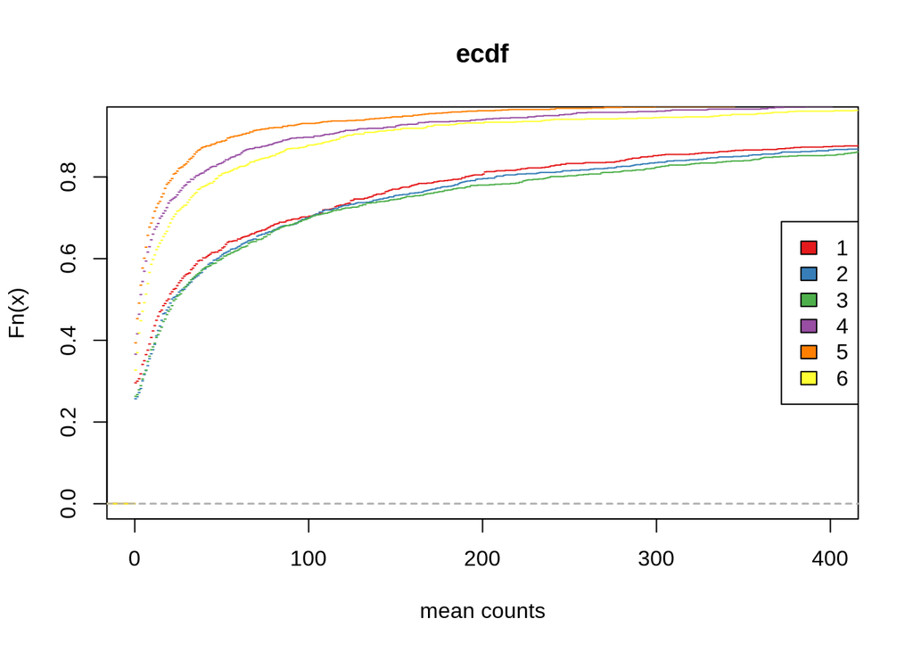

```r
multiecdf(counts(dds, normalized = F),
           xlab="mean counts", xlim=c(0, 400))
```

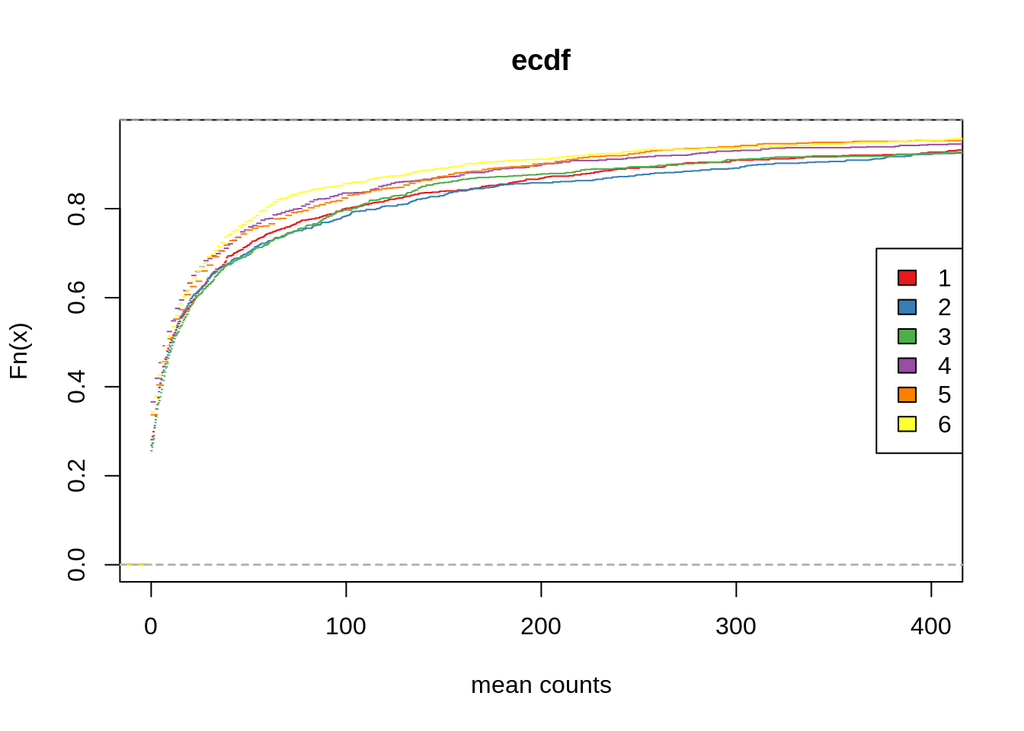

```r
multiecdf(counts(dds, normalized = T),
           xlab="mean counts", xlim=c(0, 400))
```

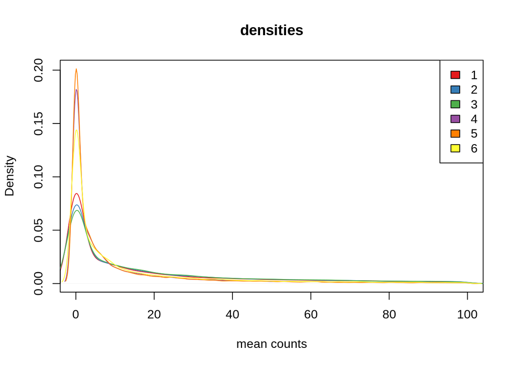

```r
multidensity(counts(dds, normalized = F),
              xlab="mean counts", xlim=c(0, 100))
```

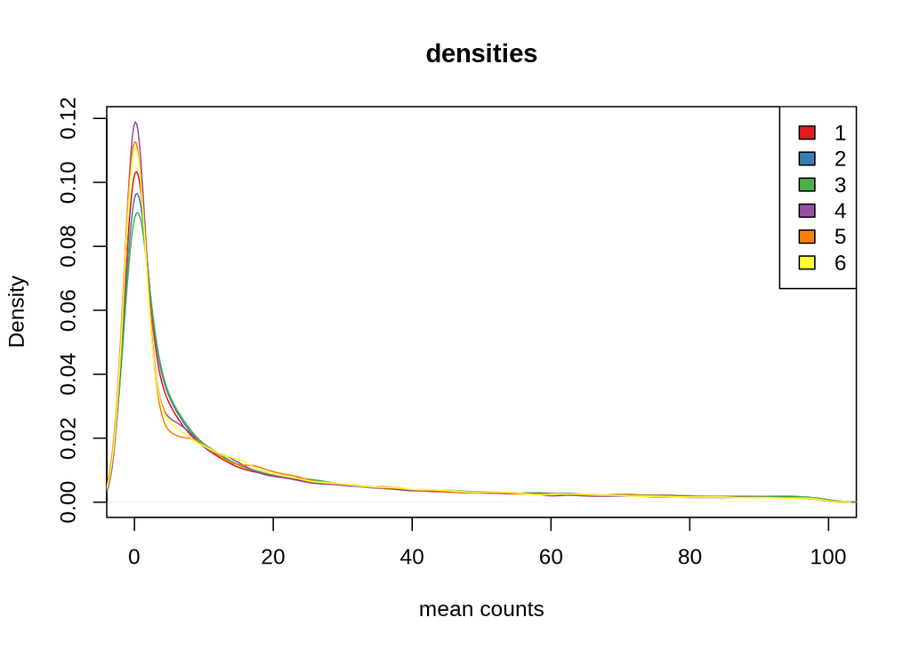

```r
multidensity(counts(dds, normalized = T),
              xlab="mean counts", xlim=c(0, 100))
```

For visual assessment of differentially expressed genes, we used heatmaps and Volcano plot.

[output not shown]

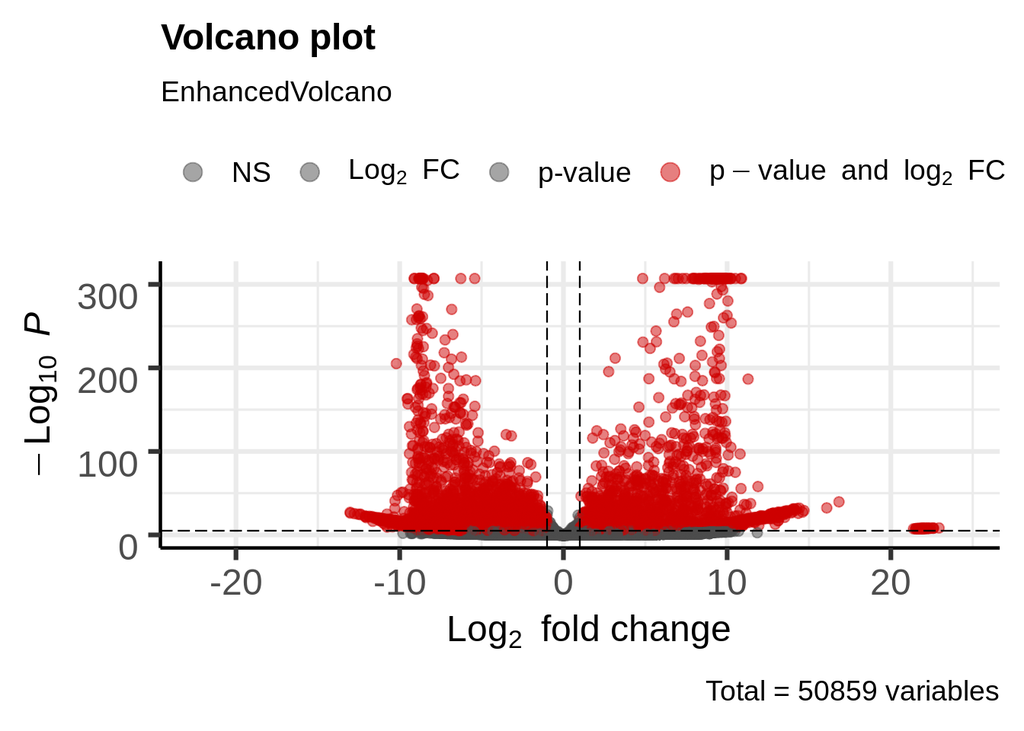

```r
dds <- estimateSizeFactors(dds)
norm_res <- results(dds)
EnhancedVolcano(norm_res,
                lab = rownames(norm_res),
                x = 'log2FoldChange',
                y = 'pvalue',
                col=c('grey30', 'grey30', 'grey30', 'red3'),
                transcriptLabSize = 0.0)
```

Write results of analysis to the file:

```r
write.csv(counts(dds, normalized=TRUE), file = '/media/kremnyov-lab/data2/20080351/fastq/res_norm_annotate')

resOrdered <- res[order(res$pvalue),]
resOrdered <- as.data.frame(resOrdered)
resOrderedSign_Minus <- filter(resOrdered, pvalue < 0.05)
write.csv(resOrderedSign_Minus, file = '/media/kremnyov-lab/data2/20080351/fastq/res_sign_annotate')

write.csv(counts(dds), file = '/media/kremnyov-lab/data2/20080351/fastq/counts')
```

# Analysis of some genes

Analysis of WNT genes:

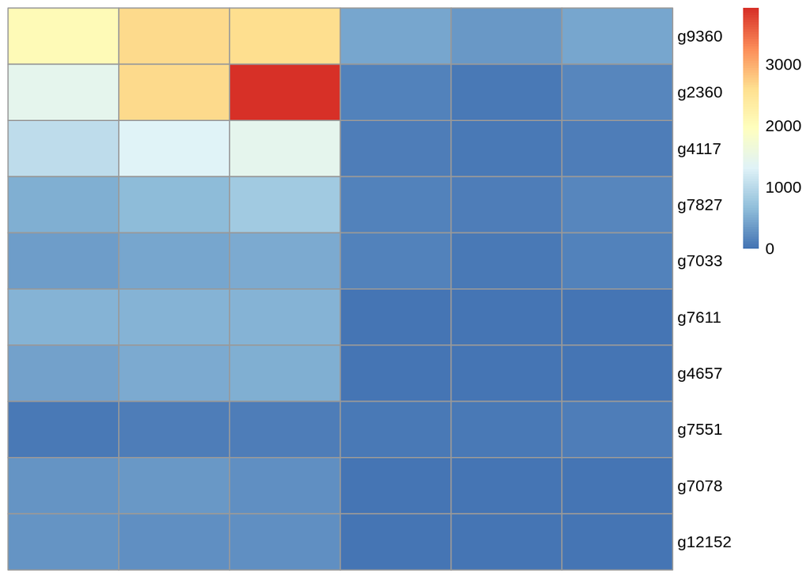

```r
wnt <- read.csv("/media/kremnyov-lab/data2/20080351/fastq/wnt/blast_dyn.fasta",
                        sep = "\t", header = F)

wnt_valuable <- subset(wnt, wnt$V11 < 2.00e-100)
wnt_valuable$gene <- lapply(strsplit(as.character(wnt_valuable$V2), "_"),"[",7)
wnt_unique <- distinct(wnt_valuable, gene, .keep_all = T)
wnt_valuable$V2 <- sapply(strsplit(as.character(wnt_valuable$V2), ".p"),"[",1)

wnt_list <- wnt_unique[,c(1, 13)]

dds_wnt = subset(dds, rownames(counts(dds, normalized=TRUE)) %in% wnt_list$gene)


ntd_wnt <- normTransform(dds_wnt)
select <- order(rowMeans(counts(dds_wnt,normalized=TRUE)),
                decreasing=TRUE)
df <- as.data.frame(colData(dds_wnt)[,c("condition")])

pheatmap(assay(dds_wnt)[select,], cluster_rows=FALSE, show_rownames=T,
         cluster_cols=FALSE)
```

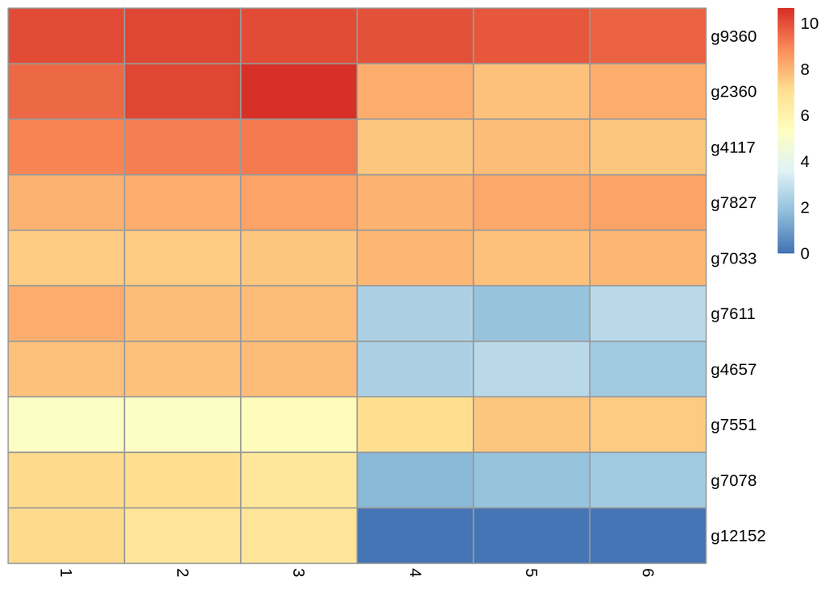

```r
pheatmap(assay(ntd_wnt)[select,], cluster_rows=FALSE, show_rownames=T,
         cluster_cols=FALSE)
```